# 1. Preparing the data

Refining the Shortest Paths (RSP) of animals tracked with acoustic transmitters in estuarine regions

Yuri Niella & Hugo Flávio

2020-06-15

## Index

1. Preparing the data
2. Refining the Shortest Paths in-water
3. Calculating utilization distribution
4. Calculating overlaps

## 1.1. Preliminary analysis of acoustic detections using actel

Analysing acoustic telemetry data requires initial filtering to exclude misleading data (e.g. false detections, detections prior to release). To overcome this issue and ensure reliable results, the RSP toolkit operates in close relationship with the **actel R package**, which filters and invalidates flawed detections. Before getting started with RSP, you will have to download actel and filter your acoustic data. Please click [here](https://github.com/hugomflavio/actel) for more information and to download actel.

To start using RSP, you can run the simplest actel analysis with the function `explore`. You can find more about how to organize your data and run this preliminary analysis in actel’s manual pages (run `?actel` after loading the library).

It is important that you save the output of the actel function, so you can later on use it in RSP. e.g.:

```
library(actel)
filtered_data <- explore(tz = "Europe/Copenhagen")
```

## 1.2. Preparing the data from your study area using actel

To recreate the shortest in-water paths of tracked animals, RSP needs a **transition layer** from your study area. You may already have a transition layer calculated for your study area, or you can use actel again to do so. First, you need to load a **shapefile** (.shp) from your study area **delimiting the land contours** using `loadShape()`. This function automatically imports your shapefile and converts it to a raster, and the corresponding pixel size can be set using the `size` argument. After loading your shapefile, you need to create your transition layer using `transitionLayer()` by choosing a number of `directions` for distance calculations (please click [here](https://mran.microsoft.com/snapshot/2016-08-05/web/packages/gdistance/vignettes/gdistance1.pdf) and see pages 2 and 3 for more information about this step):

```
water.shape <- loadShape(shape = "my_study_areas.shp", size = 0.0001)
water.transition <- transitionLayer(water.shape, directions = 16)
```

Please have in mind that not only the transition layer but also the base raster (your imported shapefile) will be required during the RSP analysis. RSP currently accepts shapefiles in both **metric** and **geographic** coordinate reference systems.

## 1.3. Checking the quality of the input files

Depending on the shapefile provided from your study area, the pixel size used and the locations of your receivers (provided earlier in the spatial dataset for actel), it may be that your receivers could end up in land during analysis. This will cause the RSP analysis to return funky results such as animal tracks crossing extensively through land. To avoid this issue, you can use the `plotRaster()` function to test the quality of the input data:

```
plotRaster(input = filtered_data, base.raster = water.shape, coord.x = "Longitude", coord.y = "Latitude")
```

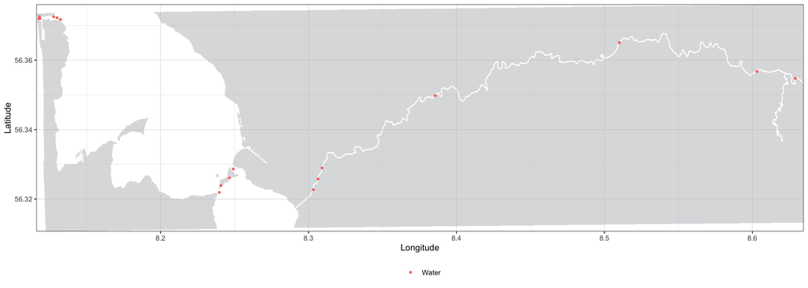

If you get a plot similar to this one, with only **Water** showing up in the legend, it means that all your receivers are placed **inside of the water** and you are all good to continue. If any receivers are **in land** they will be coloured differently in this plot. It is then necessary to either adjust your shapefile or the receiver positions in the spatial dataset before continuing.